# Investigating Hotel Booking Demand

## by Khaled Salem

## Investigation Overview

> This presentation provides an insight of the tourism and hospitality industry by investigating hotel bookings demand globally. The aim of this presentation is to present the main findings through intuitive and easy-to-follow visualizations.

## Dataset Overview

> This data set contains booking information for a city hotel and a resort hotel made worldwide, and includes information such as when the booking was made, duration of stay, the number of adults, children, and/or babies, and the number of available parking spaces, among other things from 2015 to 2017.

## Hotel Type

> There is a preference among bookings made for city hotels rather than resort hotels

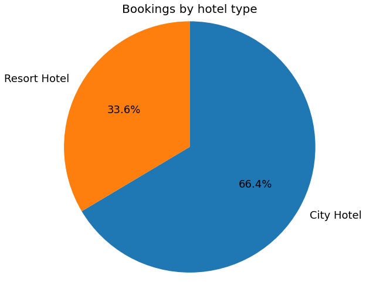

```python
hotel_types = df.hotel.value_counts()
plt.figure(figsize=(8,10))
plt.title('Bookings by hotel type', fontsize=20)
plt.pie(hotel_types,labels=hotel_types.index,startangle=90,counterclock=False,autopct='%1.1f%%',radius=1.2,textprops={'fontsize':18});
```

## Cancelled Bookings

> Cancelled bookings accounted for approximately 40% of all bookings made

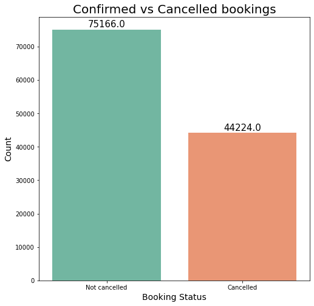

```python
cancellation_counts = df.is_canceled.value_counts()
plt.figure(figsize=(8,8))
g=sb.countplot(data=df,x='is_canceled',palette='Set2')
g.set_xticklabels(['Not cancelled','Cancelled'])
plt.title('Confirmed vs Cancelled bookings',fontsize=20)
plt.ylabel('Count',fontsize=14)
plt.xlabel('Booking Status',fontsize=14);
for bar in g.patches:
  g.annotate(format(bar.get_height(), '.1f'),
                   (bar.get_x() + bar.get_width() / 2,
                    bar.get_height()), ha='center', va='center',
                   size=15, xytext=(0, 8),
                   textcoords='offset points')
```

## Days spent in waiting list affecting booking cancellations

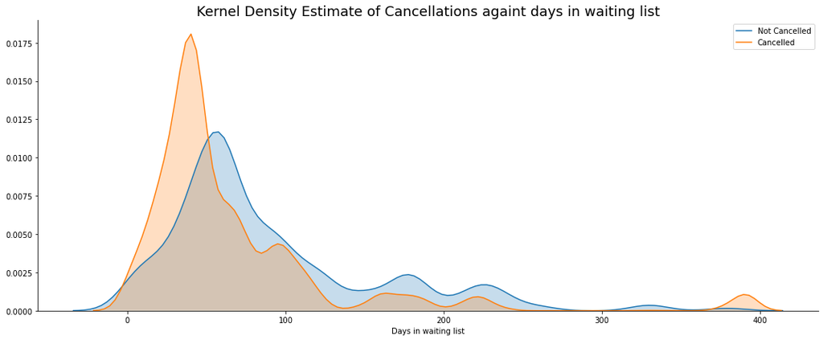

```python
sb.FacetGrid(df[df['days_in_waiting_list']>0],hue='is_canceled',height=6,aspect=2.5).map(sb.kdeplot,'days_in_waiting_list',shade=True)
plt.title('Kernel Density Estimate of Cancellations againt days in waiting list',fontsize=18)
plt.legend(['Not Cancelled','Cancelled'])
plt.xlabel('Days in waiting list');
```

## Average Daily Rate variation over the year

> The average daily rate varies at different seasons of the year, surging during the summer season and dropping during the winter season

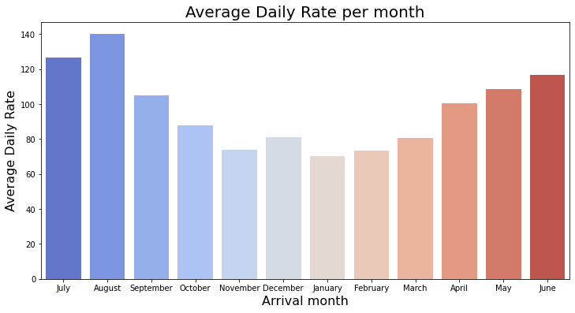

```python
plt.figure(figsize=(12,6))
sb.barplot(data=df,x='arrival_date_month',y='adr',palette='coolwarm',ci=False)
plt.title('Average Daily Rate per month',fontsize=20)
plt.ylabel('Average Daily Rate',fontsize=16)
plt.xlabel('Arrival month',fontsize=16);
```

## Payment policies set by hotels can impact cancellation rate

> An unusual correlation was discovered, in that almost all bookings at hotels that do not offer a refund (full payment is made prior to arrival) got cancelled indicating that adopting a no deposit policy may lead to lower cancellation rates

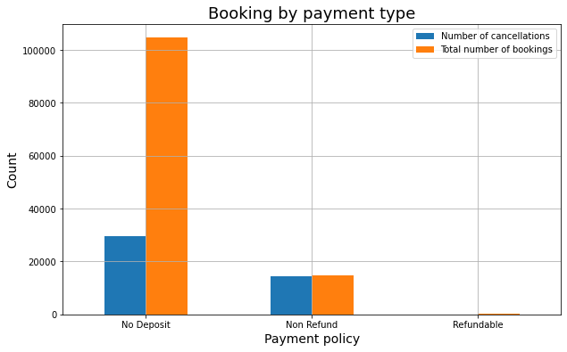

```python
deposit_cancellation = pd.concat([df.groupby('deposit_type').sum()['is_canceled'],
                                 df.deposit_type.value_counts()],axis=1)
deposit_cancellation.plot(kind='bar',figsize=(10,6))
plt.title('Booking by payment type',fontsize=18)
plt.legend(['Number of cancellations','Total number of bookings'])
plt.xticks(rotation=0)
plt.grid()
plt.xlabel('Payment policy',fontsize=14)
plt.ylabel('Count',fontsize=14);
```

## Average Daily Rate is directly proportional with number of adults

> As the number of adults increases, the average daily rate rises and hence there is positive correlation between them

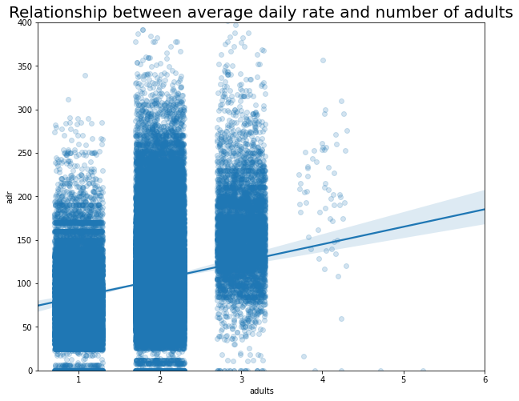

```python
plt.figure(figsize=(10,8))
sb.regplot(data=df,x='adults',y='adr',x_jitter=0.3,scatter_kws={'alpha':0.2})
plt.title('Relationship between average daily rate and number of adults',fontsize=20)
plt.xlim(0.5,6)
plt.ylim(0,400);
```

## Average daily rate fluctuates over the year for both types of hotels

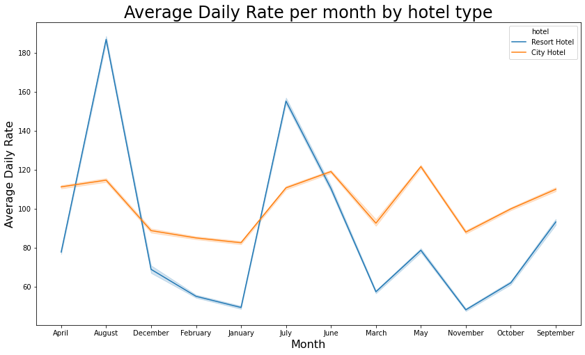

```python
plt.figure(figsize=(14,8))
sb.lineplot(data=df,x='arrival_date_month',y='adr',hue='hotel')
plt.title('Average Daily Rate per month by hotel type', fontsize=24)
plt.xlabel('Month',fontsize=16)
plt.ylabel('Average Daily Rate',fontsize=16);
```